# Notebook

Load the image and cached texture features.

```python
import warnings
warnings.filterwarnings('ignore')

import skimage
from skimage.color import color_dict
import cv2
import numpy as np

# img_name = 'Resized_1_region2'
# img_name = 'Resized_2_region'
img_name = 'Resized_6_region'

features = np.load('/home/yuncong/my_csd181_scratch/'+img_name+'_features.npy')
print features.shape

img = cv2.imread('/home/yuncong/my_csd181_scratch/'+img_name+'.png', 0)

height, width, n_feat = features.shape
features = features[200:1400, 200:3000, :]
img = img[200:1400, 200:3000]
```

[output not shown]

Oversegment the image into superpixels.

```python
from skimage.segmentation import slic, mark_boundaries
from skimage.color import gray2rgb
from skimage.measure import regionprops
from scipy.spatial.distance import pdist, squareform
from skimage.util import img_as_ubyte
from IPython.display import FileLink

img_rgb = gray2rgb(img)

segmentation = slic(img_rgb, compactness=10, sigma=20)
# segmentation = slic(img_rgb, compactness=3, sigma=20)

n_superpixels = segmentation.max()+1

boundary_img = mark_boundaries(img_rgb, segmentation)

sp_props = regionprops(segmentation+1, intensity_image=img, cache=True)
sp_centroids = np.array([s.centroid for s in sp_props])
# sp_wcentroids = np.array([s.weighted_centroid for s in sp_props])
sp_centroid_dist = pdist(sp_centroids)
sp_centroid_dist_matrix = squareform(sp_centroid_dist)

cv2.imwrite(img_name+'_superpixelized.jpg', img_as_ubyte(boundary_img))
FileLink(img_name+'_superpixelized.jpg')
```

Resized_6_region_superpixelized.jpg

Group the features into 10 clusters using k-means. Each cluster is called a *texton*.

```python
%%time
from sklearn.cluster import MiniBatchKMeans

num_textons = 10
kmeans_model = MiniBatchKMeans(num_textons)
kmeans_model.fit(features.reshape(-1, features.shape[-1]))

from skimage.color import label2rgb

textonmap = kmeans_model.labels_.reshape(features.shape[:2])
textonmap_rgb = label2rgb(textonmap, image=None, colors=None, alpha=0.3, image_alpha=1)

textonmap_with_boundary = mark_boundaries(textonmap_rgb, segmentation)

vis = img_as_ubyte(textonmap_with_boundary)
for s in range(n_superpixels):
    vis = cv2.putText(vis, str(s), tuple(np.floor(sp_centroids[s][::-1]).astype(np.int)), cv2.FONT_HERSHEY_COMPLEX_SMALL,
                     0.8, ((0,0,0)), 1)

cv2.imwrite(img_name+'_textonmap_with_boundary.jpg', vis)
FileLink(img_name+'_textonmap_with_boundary.jpg')
```

```
CPU times: user 22.8 s, sys: 7.52 s, total: 30.4 s
Wall time: 19 s
```

```python
FileLink(img_name+'_textonmap_with_boundary.jpg')
```

Resized_6_region_textonmap_with_boundary.jpg

Compute the connectivity matrix of the superpixels.

```python
from skimage.morphology import disk
from skimage.filter.rank import gradient
from scipy.sparse import coo_matrix

edge_map = gradient(segmentation.astype(np.uint8), disk(3))
neighbors = [set() for i in range(n_superpixels)]
for y,x in zip(*np.nonzero(edge_map)):
    neighbors[segmentation[y,x]] |= set(segmentation[y-1:y+1,x-1:x+1].ravel())

# connectivity_matrix = np.zeros((n_segmentation, n_segmentation), dtype=np.bool)
rows = np.hstack([s*np.ones((len(neighbors[s]),), dtype=np.int) for s in range(n_superpixels)])
cols = np.hstack([list(neighbors[s]) for s in range(n_superpixels)])
data = np.ones((cols.size, ), dtype=np.bool)
connectivity_matrix = coo_matrix((data, (rows, cols)), shape=(n_superpixels,n_superpixels))
# plt.matshow(connectivity_matrix.todense(), cmap=plt.cm.Greys_r)
# plt.show()
```

Compute the texton histogram of each superpixel. Also compute the histogram distance between each pair of superpixels. The distance measure is the chi-square distance.

```python
sample_interval = 1
gridy, gridx = np.mgrid[:img.shape[0]:sample_interval, :img.shape[1]:sample_interval]

all_seg = segmentation[gridy.ravel(), gridx.ravel()]
all_label = textonmap[gridy.ravel(), gridx.ravel()]
sp_label_hist = np.array([np.bincount(all_label[all_seg == s], minlength=num_textons)
                 for s in range(n_superpixels)])

row_sums = sp_label_hist.sum(axis=1)
sp_label_hist_normalized = sp_label_hist.astype(np.float) / row_sums[:, np.newaxis]

def chi2(u,v):
    return np.sum(np.where(u+v!=0, (u-v)**2/(u+v), 0))

eps = 0.001
def kl(u,v):
    return np.sum((u+eps)*np.log((u+eps)/(v+eps)))

# D = pdist(sp_label_hist_normalized, 'euclidean')
D = pdist(sp_label_hist_normalized, chi2)

hist_distance_matrix = squareform(D)

# fig = plt.figure()
# ax = fig.add_subplot(111)
# cax = ax.matshow(hist_distance_matrix)
# fig.colorbar(cax)
# plt.show()
```

To find salient superpixels, we calculate a saliency map.

**First approach:** Use the distance between texton histogram of each superpixel vs. histogram of the overall image.

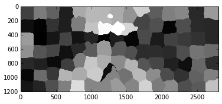

```python
overall_texton_hist = np.bincount(textonmap.flat)
overall_texton_hist_normalized = overall_texton_hist.astype(np.float) / overall_texton_hist.sum()
saliency_score = np.array([chi2(sp_hist, overall_texton_hist_normalized) for sp_hist in sp_label_hist_normalized])

colors = [np.ones((3,)) * c for c in (saliency_score-saliency_score.min())/(saliency_score.max()-saliency_score.min())]
plt.imshow(label2rgb(segmentation, colors=colors))
plt.show()
```

**Second approach:** The saliency of superpixel $i$ is the sum of its difference with all the other superpixels: $S(i) = \sum_{j\ne i}D(i,j).$ The difference between two superpixels is defined as: $D(i,j) = \exp \left(- \frac{d_{spatial}(i,j)}{a} \right) \cdot d_{texton}(i,j)$ This is the texton histogram distance weighted by the spatial distance. $a$ is the average diameter of a superpixel.

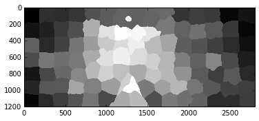

```python
sp_diameters = np.array([s.equivalent_diameter for s in sp_props])
sp_diameter_mean = sp_diameters.mean()

saliency_score = np.zeros((n_superpixels,))
for i in range(n_superpixels):
#     saliency_score[i] = np.sum([np.log(1 + sp_centroid_dist_matrix[i,j] / sp_diameter_mean) + hist_distance_matrix[i,j]
#                                 for j in range(n_superpixels) if j != i ])
#     saliency_score[i] = np.sum([np.log(1 + sp_centroid_dist_matrix[i,j] / sp_diameter_mean)
#                                 for j in range(n_superpixels) if j != i ])
#     saliency_score[i] = np.sum([1./np.log(1 + sp_centroid_dist_matrix[i,j] / sp_diameter_mean) * hist_distance_matrix[i,j]
#                             for j in range(n_superpixels) if j != i ])
    saliency_score[i] = np.sum([np.exp(- sp_centroid_dist_matrix[i,j] / sp_diameter_mean) * hist_distance_matrix[i,j]
                            for j in range(n_superpixels) if j != i ])

colors = [np.ones((3,)) * c for c in (saliency_score-saliency_score.min())/(saliency_score.max()-saliency_score.min())]
plt.imshow(label2rgb(segmentation, colors=colors))
plt.show()
```

Both saliency maps look reasonable.

Now we find the most salient superpixel, and use it as a seed to find a group of connected superpixels with similar texton histograms.

```python
i = saliency_score.argmax()
curr_cluster = [i]
frontier = [i]
while len(frontier) > 0:
#     print 'frontier', frontier
    i = frontier.pop(-1)
    for j in neighbors[i]:
        if j != i and j not in curr_cluster and hist_distance_matrix[curr_cluster,j].mean() < 0.8:
            curr_cluster.append(j)
            frontier.append(j)
print 'curr_cluster', curr_cluster

propagate_selection = np.equal.outer(segmentation, curr_cluster).any(axis=2)
selection = mark_boundaries(img, propagate_selection)
cv2.imwrite(img_name+'_selection.jpg', img_as_ubyte(selection))
FileLink(img_name+'_selection.jpg')
```

```
curr_cluster [22, 21, 23, 20]
```

Resized_6_region_selection.jpg